# Data Visualization with Matplotlib

## Working with 2D Data and Images

### Displaying 2D Arrays as Images

In astronomy, we often work with 2D data - CCD images, spectrograms, or any data that varies in two dimensions. Let's start with a simple example:

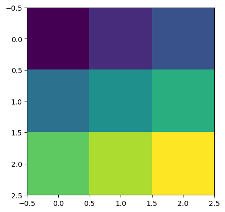

```python
# Create a simple 3x3 array
data = np.array([[1, 2, 3],
                 [4, 5, 6],
                 [7, 8, 9]])

plt.imshow(data)
plt.show()
```

The `imshow()` function converts each number in the array to a color. By default, low values are purple/blue and high values are yellow. Let's add a colorbar to see this mapping:

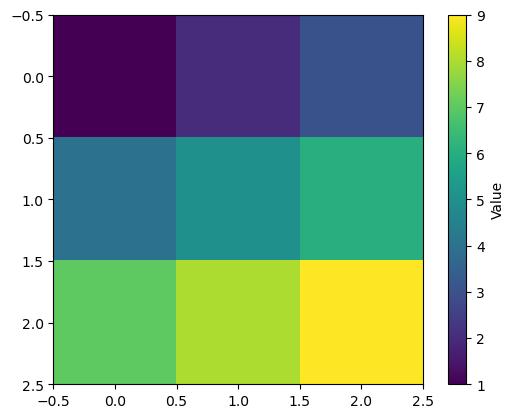

```python
plt.imshow(data)
plt.colorbar(label='Value')  # Shows the mapping and adds a label
plt.show()
```

The colorbar shows which colors correspond to which values. Always label your colorbar to indicate what the values represent!

### Creating a More Realistic Example

```python
# Create coordinate grids
x = np.linspace(-20, 20, 100)
y = np.linspace(-20, 20, 100)
X, Y = np.meshgrid(x, y)
```

The `meshgrid()` function creates 2D coordinate arrays from 1D arrays. Think of it as creating a grid where every point has an (X, Y) coordinate.

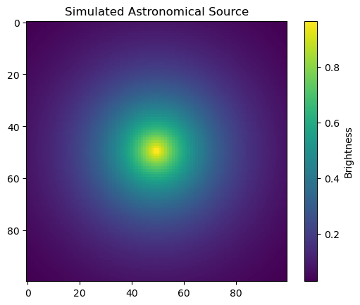

```python
# Calculate distance from center
radius = np.sqrt(X**2 + Y**2)

# Create exponential brightness profile
brightness = np.exp(-radius/8)

plt.imshow(brightness)
plt.colorbar(label='Brightness')
plt.title('Simulated Astronomical Source')
plt.show()
```

This creates a circular pattern that's brightest at the center and fades exponentially - similar to how we might observe a distant galaxy or star.

By default, matplotlib puts the origin (0,0) at the top-left corner, like computer graphics. But astronomical FITS images put (0,0) at the bottom-left:

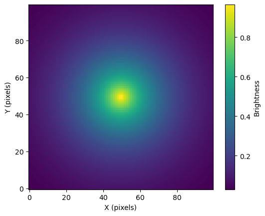

```python
plt.imshow(brightness, origin='lower')  # Put origin at bottom-left
plt.colorbar(label='Brightness')
plt.xlabel('X (pixels)')
plt.ylabel('Y (pixels)')
plt.show()
```

Always use `origin='lower'` for astronomical images, or your data will appear flipped vertically!

### Choosing Appropriate Colormaps

Different colormaps serve different purposes. Let's compare a few:

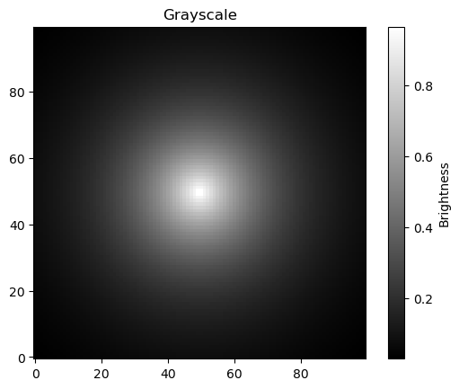

```python
plt.imshow(brightness, origin='lower', cmap='gray')
plt.colorbar(label='Brightness')
plt.title('Grayscale')
plt.show()
```

Grayscale is ideal for printed publications. For presentations or digital viewing, try:

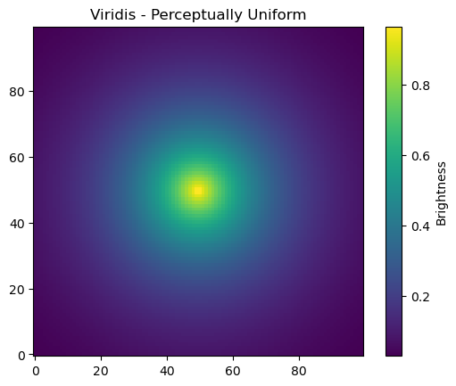

```python
plt.imshow(brightness, origin='lower', cmap='viridis')
plt.colorbar(label='Brightness')
plt.title('Viridis - Perceptually Uniform')
plt.show()
```

Viridis is "perceptually uniform" - equal steps in data value appear as equal steps in perceived color. Avoid the 'jet' colormap - such rainbow-like colors might create artificial perception that aren't in your data!

### Adjusting Image Scaling

When your data has a large dynamic range (very bright and very faint features), linear scaling won't show everything. Let's demonstrate with two separate plots:

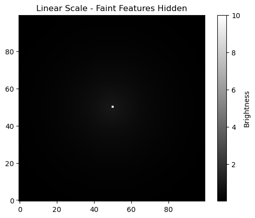

```python
# Add a bright point source to our image
image_with_star = brightness.copy()
image_with_star[50, 50] = 10  # Very bright pixel at position (50,50)

# Linear scale - can't see the faint extended emission
plt.imshow(image_with_star, origin='lower', cmap='gray')
plt.colorbar(label='Brightness')
plt.title('Linear Scale - Faint Features Hidden')
plt.show()
```

Now try logarithmic scaling:

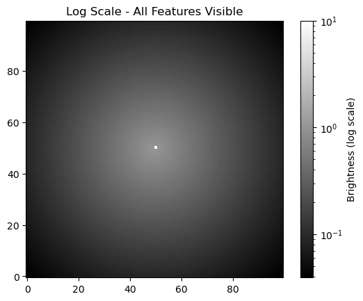

```python
from matplotlib.colors import LogNorm

# Logarithmic scale - reveals faint features
plt.imshow(image_with_star + 0.01,  # Add small value to avoid log(0)
           origin='lower',
           cmap='gray',
           norm=LogNorm())
plt.colorbar(label='Brightness (log scale)')
plt.title('Log Scale - All Features Visible')
plt.show()
```

The `LogNorm()` class changes how values map to colors, using a logarithmic scaling. This is essential for astronomical images that often contain both bright stars and faint nebulosity.